# Figuring out how to quantify seasonality index

# 1 setup

> load master dataset, create a couple simple time series from subset of 2 sites from LUQ and UMR

# 2 testing out seasonality index for 2 sites following method used by Moatar et al 2017 paper + Lian et al 2016, and described by Walsh and Lawler 1981

```r
# summarize Si by monthly average
luqmonthly <- luqtest %>%
  group_by(month) %>%
  summarize(monthly_avg = mean(value))

# summarize Si by annual average
luqannual <- luqtest %>%
  group_by(year) %>%
  summarize(annual_avg = mean(value))

# average of annual averages (maybe just take overall average of all points here instead? doesn't change the value much though)
luqoverallavg <- mean(luqannual$annual_avg)
luqoverallavg
```

```
## [1] 706.762
```

```r
luqindex <- luqmonthly %>%
  mutate(annual_avg=luqoverallavg) %>% # take overall average from above
  mutate(monthly_dev = abs(monthly_avg - annual_avg)) %>% # abs value of monthly deviations difference from Walsh 1981 is not dividing by 12 here because that only makes sense for cumulative things like flux or precip but not concentrations
  mutate(sum_dev = sum(monthly_dev)) %>% # sum of monthly deviations
  mutate(seasonality_index=sum_dev/annual_avg) # SI is sum of monthly deviations/overall average

unique(luqindex$seasonality_index)
```

```
## [1] 0.4336107
```

```r
# summarize Si by monthly average
umrmonthly <- umrtest %>%
  group_by(month) %>%
  summarize(monthly_avg = mean(value))

# summarize Si by annual average
umrannual <- umrtest %>%
  group_by(year) %>%
  summarize(annual_avg = mean(value))

# average of annual averages
umroverallavg <- mean(umrannual$annual_avg)
umroverallavg
```

```
## [1] 127.2238
```

```r
umrindex <- umrmonthly %>%
  mutate(annual_avg=umroverallavg) %>%
  mutate(monthly_dev = abs(monthly_avg - annual_avg)) %>%
  mutate(sum_dev = sum(monthly_dev)) %>%
  mutate(seasonality_index=sum_dev/annual_avg)

unique(umrindex$seasonality_index)
```

```
## [1] 3.393599
```

> this shows that the SI for the Luquillo site is 0.4336107 and the SI for the UMR site is 3.393599 which makes sense! This only works though when omitting the part of dividing my 12 as in Walsh and Lian et al’s formulas. But I think this makes sense since our annual average DSi conc is not a cumulation of monthly DSi (as would be the case for the SI that was origingally made for precipication)

/

/

/

# 3 !! using MASTER dataset/noncontinuous Si data !! calculating SI for all sites

> similar to the above test code but grouping by LTER, site, variable to get monthly averages

```r
# summarize Si by monthly average
sisynmonthly <- sisyn %>%
  group_by(LTER, site, variable, month) %>%
  summarize(monthly_avg = mean(value))

# summarize Si by overall average
sisynannual <- sisyn %>%
  group_by(LTER, site, variable) %>%
  summarize(grand_avg = mean(value))

#join grand mean values to monthly averages
sisynindex <- left_join(sisynmonthly, sisynannual)
```

> **Here’s the main chunk of code to look at, since this calculates the actual seasonality index for all our data**

```r
sisynindex <- sisynindex %>%
  mutate(monthly_dev = abs(monthly_avg - grand_avg)) %>%
  mutate(sum_dev = sum(monthly_dev)) %>%
  mutate(LTER, site, variable) %>%
  mutate(seas_index=sum_dev/grand_avg) %>%
  distinct(LTER, site, variable, seas_index)
```

> checking how using the interpolated Si data changes the SI (a lot)

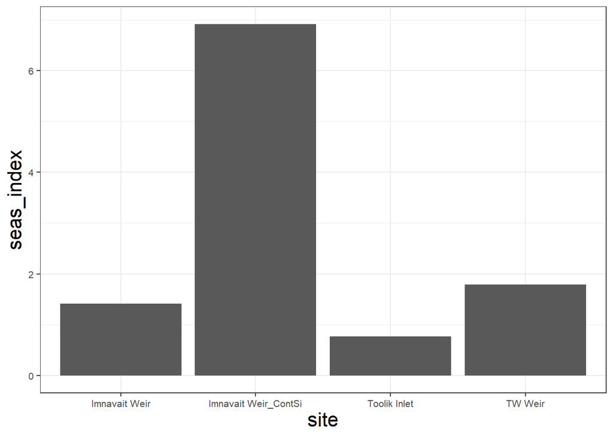

## 3.1 DSi seasonality by LTER

> a couple ways to look at SI for DSi from long term sites

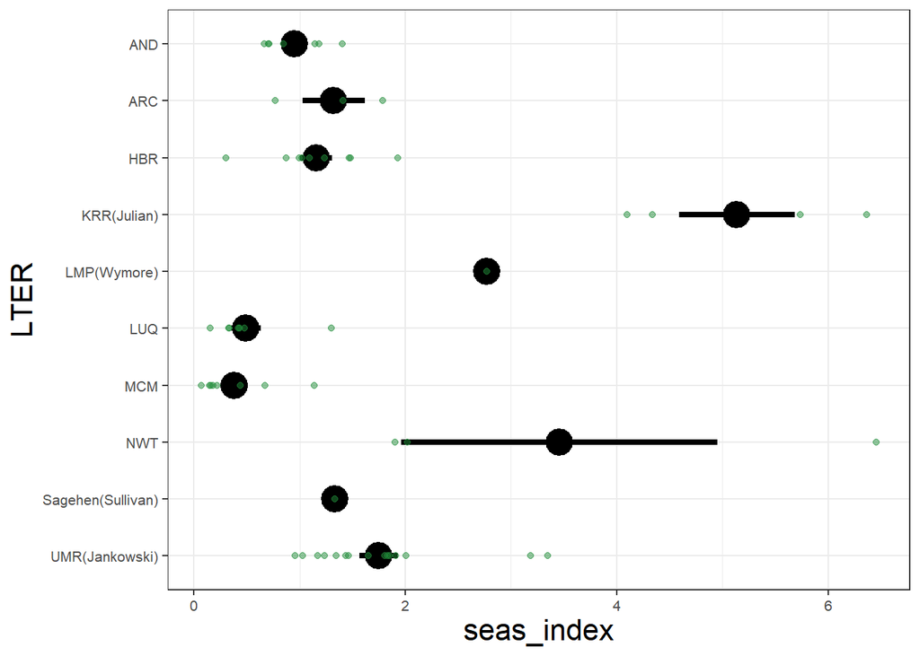

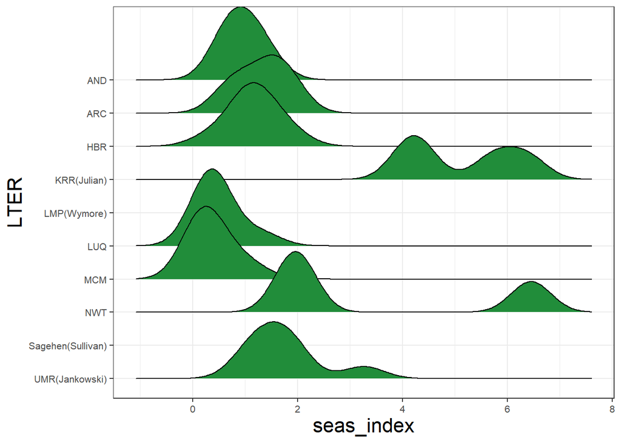

## 3.2 seasonality of DSi, discharge, a couple other things

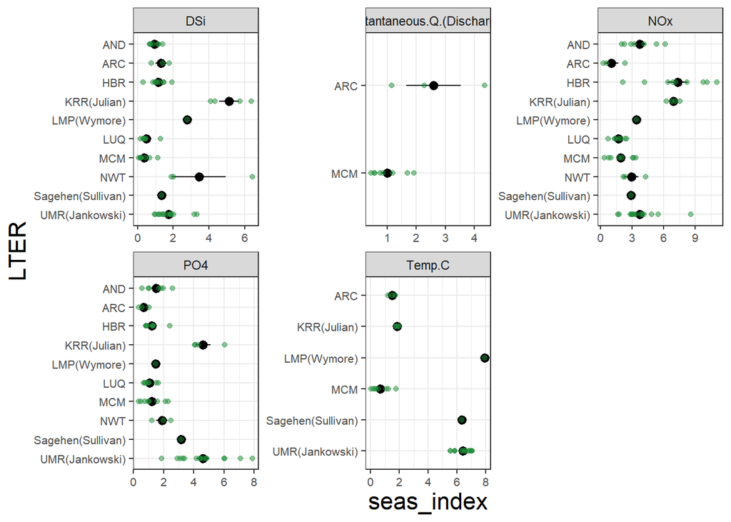

> checking up on why the SI is so low for arctic sites etc, but obviously because there isn’t year round data so maybe we aren’t able to include these unless we add 0s for frozen months

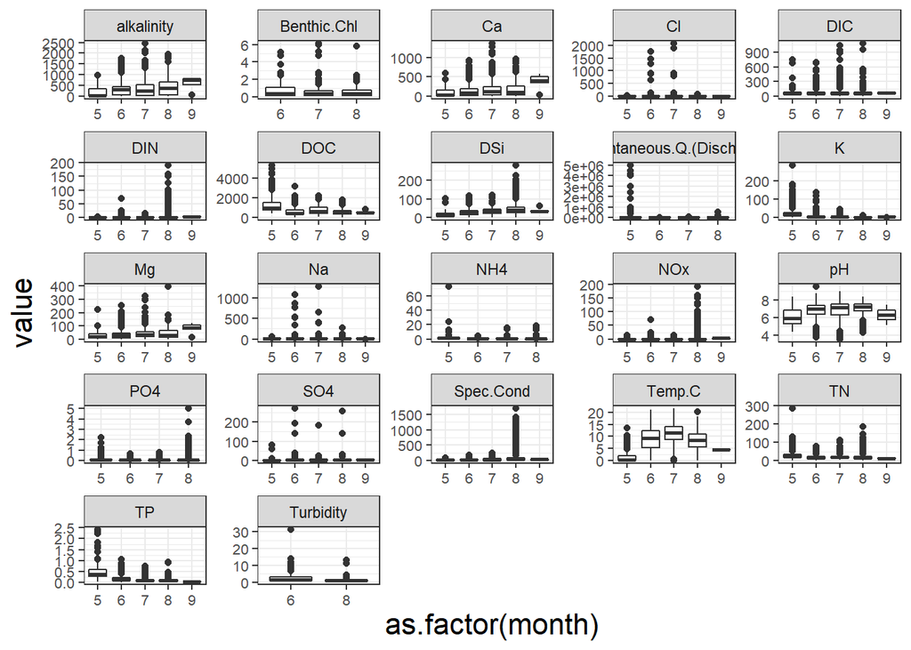

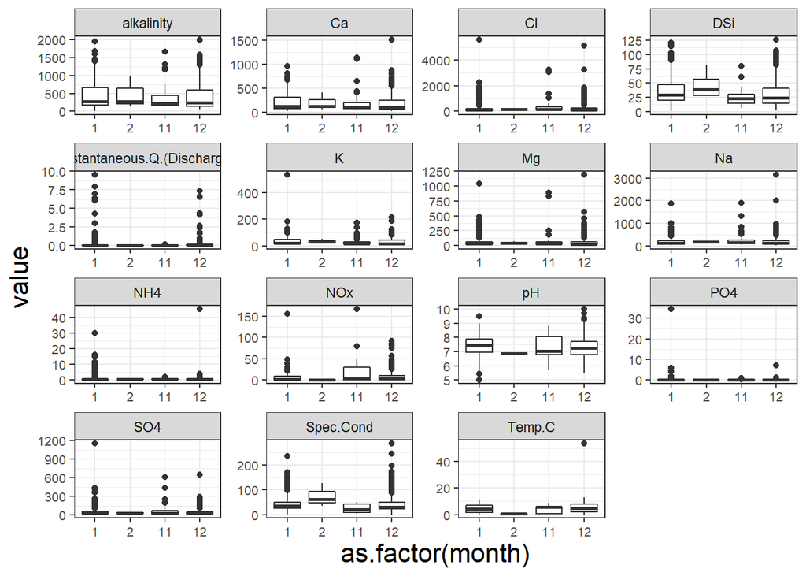

## 3.3 maps and latitude effects on seasonality index

> importing lat-long data and having a quick look- looks like Sagehen needs to swap hemispheres

> also this lat-long data doesn’t include our most up to date list of long term sites so need to change that at some point

> SI for DSi concentration

[interactive chart not shown]

> SI for water temp

[interactive chart not shown]

> quick look at absolute latitude vs SI but it’s not quite as clear as you’d expect since this doesn’t include year-round data or interpolated data from some of the sites

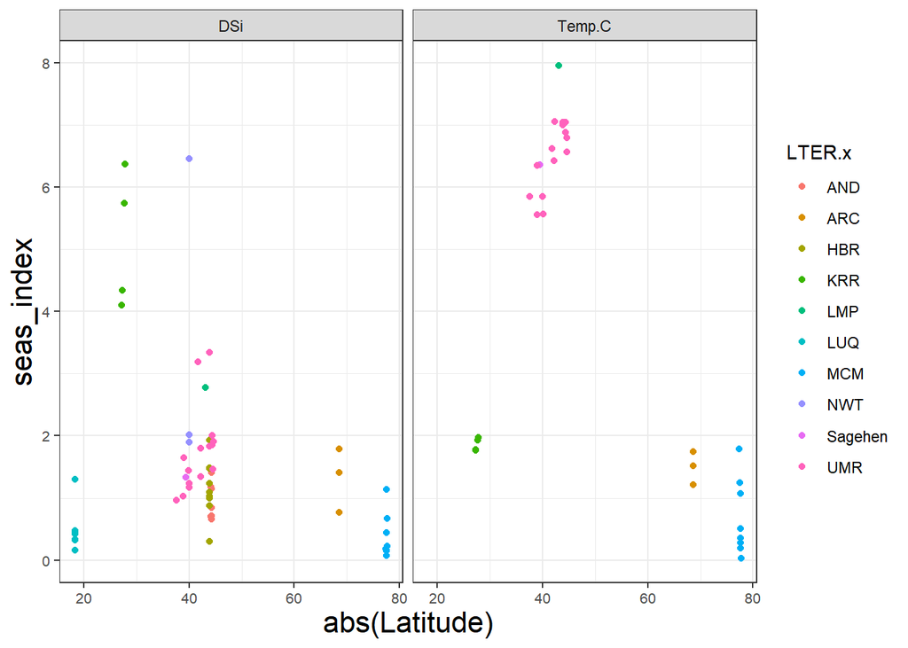

## 3.4 A quick look at “annual seasonality” - monthly deviations for each year instead of from the grand mean across years, to see if this tells us anything about changes in seasonality over time

```r
# summarize Si by monthly average
sisynmonthly <- sisyn %>%
  group_by(LTER, site, variable, year, month) %>%
  summarize(monthly_avg = mean(value))

# summarize Si by overall average
sisynannual <- sisyn %>%
  group_by(LTER, site, year, variable) %>%
  summarize(annual_avg = mean(value))

#join grand mean values to monthly averages
sisynindex <- left_join(sisynmonthly, sisynannual)

sisynindex_annual <- sisynindex %>%
  mutate(monthly_dev = abs(monthly_avg - annual_avg)) %>%
  group_by(LTER, site, variable, year) %>%
  summarize(sum_dev = sum(monthly_dev),
            seas_index = unique(sum_dev/annual_avg)) #
```

> a couple ways to visualize if within-year seasonality changes over time

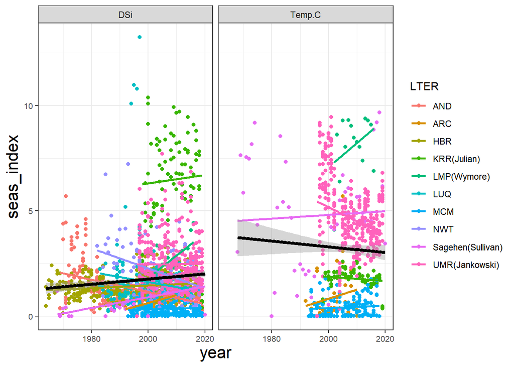

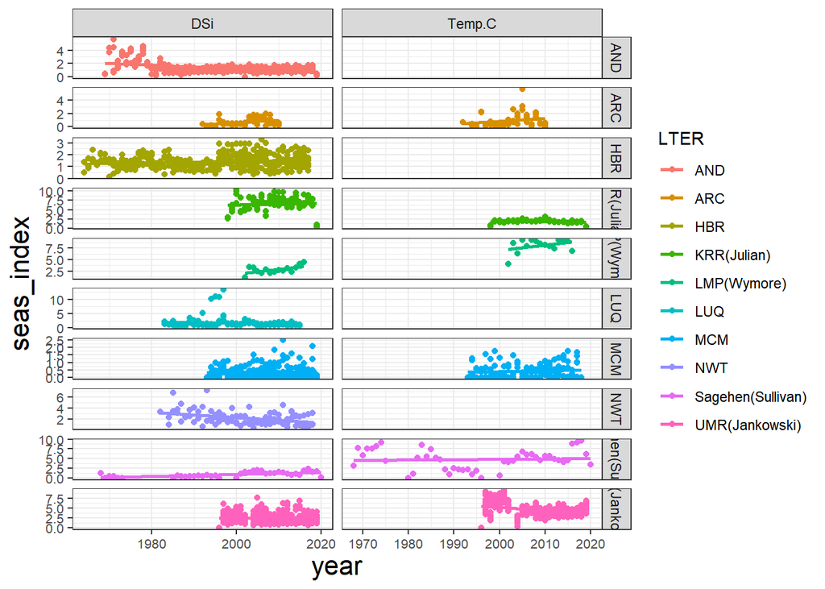

> and then calculating + plotting slopes of the seasonality index over time

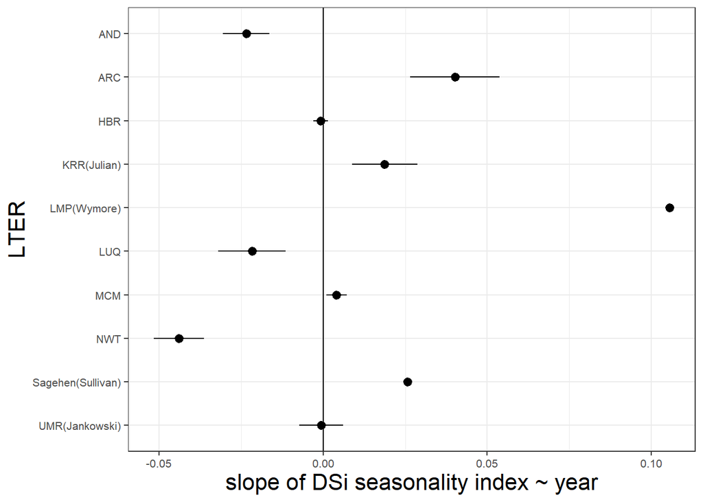

## 3.5 a super quick attempt at looking at how monthly averages have changed over time for each month and site, to get at whether certain months are increasing or decreasing

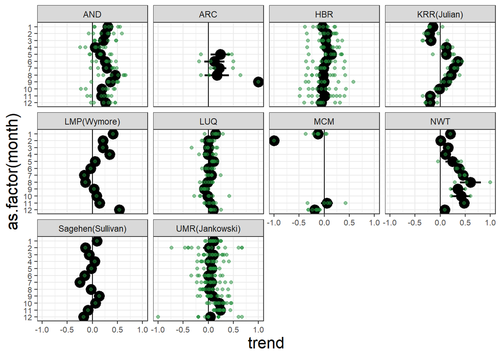

# 4 !! using daily WRTDS output dataset/continuous Si data !! calculating SI for all sites

> For this I have just copied in the above code used for the ‘master dataset’

> Import data for WRTDS daily results

```
## # A tibble: 6 x 10
##       Q ConcDay FluxDay FNConc  FNFlux site   dates      month  year LTER
##   <dbl>   <dbl>   <dbl>  <dbl>   <dbl> <chr>  <date>     <dbl> <dbl> <chr>
## 1 4749    0.622 255285.  0.612 542351. ALBION 1981-10-01    10  1981 NWT
## 2 4744.   0.625 256033.  0.620 538753. ALBION 1981-10-02    10  1981 NWT
## 3 4739.   0.629 257461.  0.621 504899. ALBION 1981-10-03    10  1981 NWT
## 4 4734.   0.633 258885.  0.638 547935. ALBION 1981-10-04    10  1981 NWT
## 5 4728.   0.637 260305.  0.631 432823. ALBION 1981-10-05    10  1981 NWT
## 6 4723.   0.641 261722.  0.634 485533. ALBION 1981-10-06    10  1981 NWT
```

```r
# summarize Si by monthly average
wrtdsmonthly <- wrtds_long %>%
  group_by(LTER, site, variable, month) %>%
  summarize(monthly_avg = mean(value))

# summarize Si by overall average
wrtdsannual <- wrtds_long %>%
  group_by(LTER, site, variable) %>%
  summarize(grand_avg = mean(value))

#join grand mean values to monthly averages
wrtdsindex <- left_join(wrtdsmonthly, wrtdsannual)
```

> **Here’s the main chunk of code to look at, since this calculates the actual seasonality index for all our data**

```r
wrtdsindex <- wrtdsindex %>%
  mutate(monthly_dev = abs(monthly_avg - grand_avg)) %>%
  mutate(sum_dev = sum(monthly_dev)) %>%
  mutate(LTER, site, variable) %>%
  mutate(wrtds_seas_index=sum_dev/grand_avg) %>%
  distinct(LTER, site, variable, wrtds_seas_index)
```

> Need to figure out why these NAs are here!

```
##      LTER               site             variable         wrtds_seas_index
##  Length:260         Length:260         Length:260         Min.   : 0.3068
##  Class :character   Class :character   Class :character   1st Qu.: 1.7385
##  Mode  :character   Mode  :character   Mode  :character   Median : 4.9242
##                                                           Mean   : 6.5168
##                                                           3rd Qu.: 9.0840
##                                                           Max.   :19.8763
##                                                           NA's   :14
```

## 4.1 DSi seasonality by LTER

> a couple ways to look at SI for DSi from long term sites, looks way better than the non-continuous data!

```
## $y
## [1] "seasonality index for daily DSi conc"
##
## attr(,"class")
## [1] "labels"
```

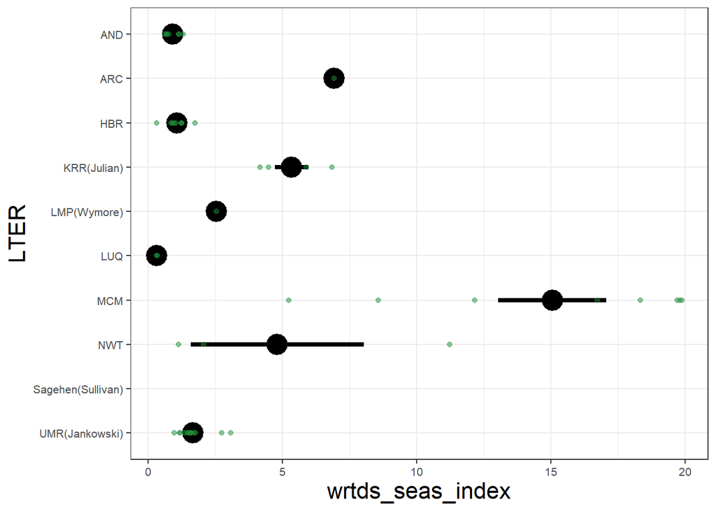

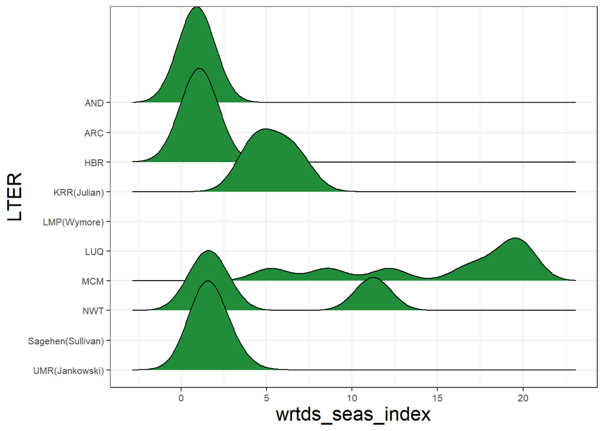

## 4.2 seasonality of DSi, discharge, flux

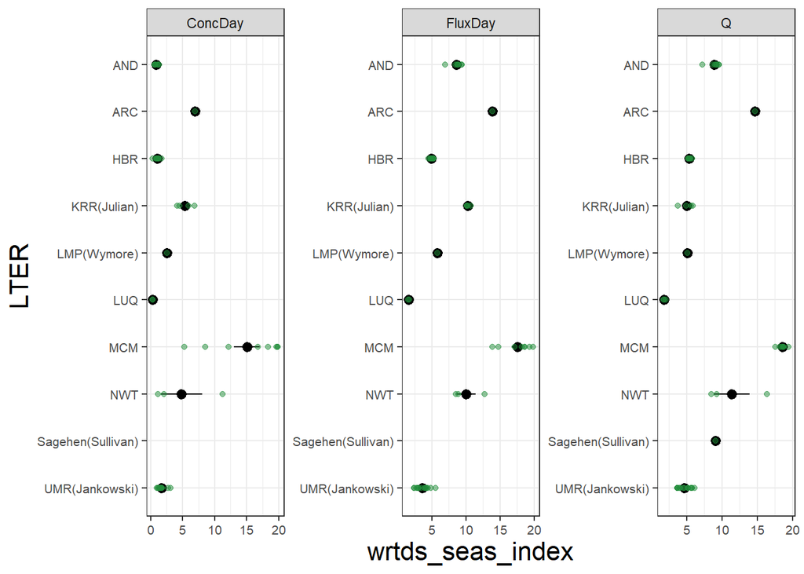

> checking again on the LTERs with data interpolated for winter, looks better with this data but something weird with MCM having data for july and august for everything besides Q….????

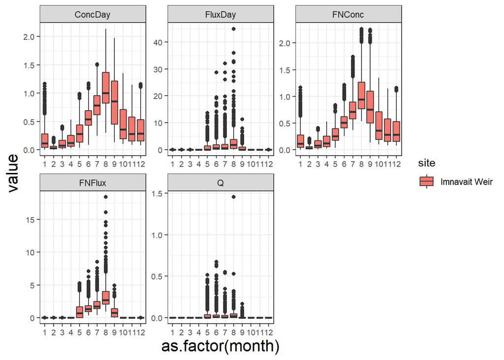

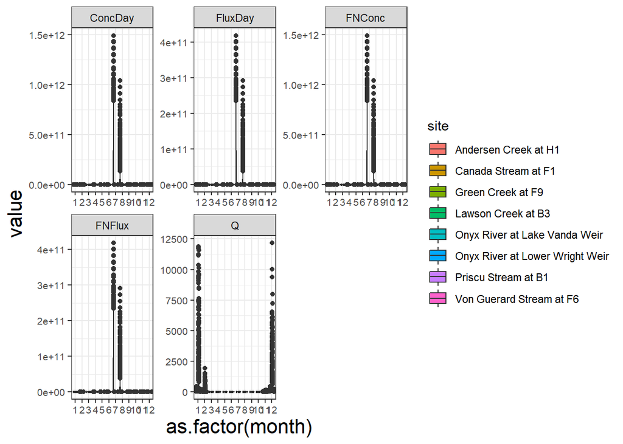

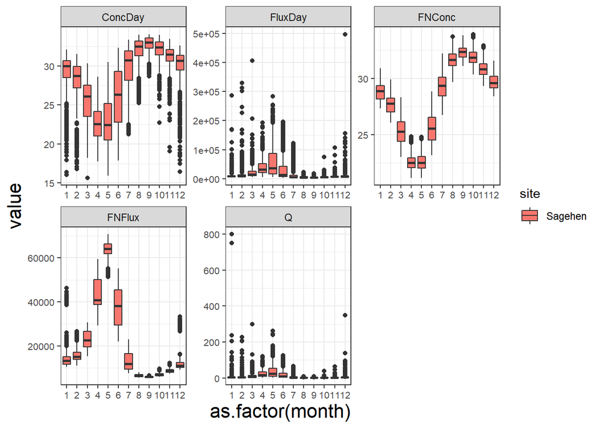

## 4.3 maps and latitude effects on seasonality index

> Sagehen should still be in the correct hemisphere now

> also this lat-long data doesn’t include our most up to date list of long term sites so need to change that at some point

> SI for DSi concentration

[interactive chart not shown]

> Ok, this makes a lot more sense now with this data- seasonality is very nicely correlated with DSi conc, flux, and discharge (would be a red flag if this weren’t the case)

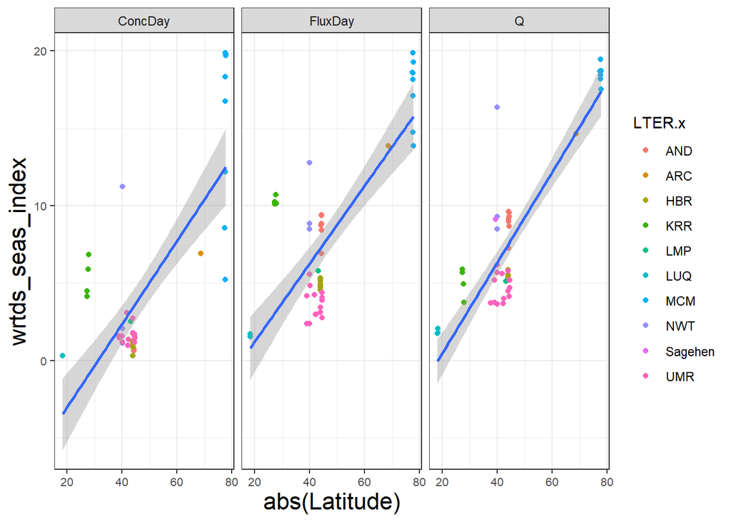

## 4.4 A quick look at “annual seasonality” - monthly deviations for each year instead of from the grand mean across years, to see if this tells us anything about changes in seasonality over time

```r
# summarize Si by monthly average
wrtdsmonthly <- wrtds_long %>%
  group_by(LTER, site, variable, year, month) %>%
  summarize(monthly_avg = mean(value))

# summarize Si by overall average
wrtdsannual <- wrtds_long %>%
  group_by(LTER, site, year, variable) %>%
  summarize(annual_avg = mean(value))

#join grand mean values to monthly averages
wrtdsindex <- left_join(wrtdsmonthly, wrtdsannual)

wrtdsindex_annual <- wrtdsindex %>%
  mutate(monthly_dev = abs(monthly_avg - annual_avg)) %>%
  group_by(LTER, site, variable, year) %>%
  summarize(sum_dev = sum(monthly_dev),
            wrtds_seas_index = unique(sum_dev/annual_avg)) #
```

> a couple ways to visualize if within-year seasonality changes over time

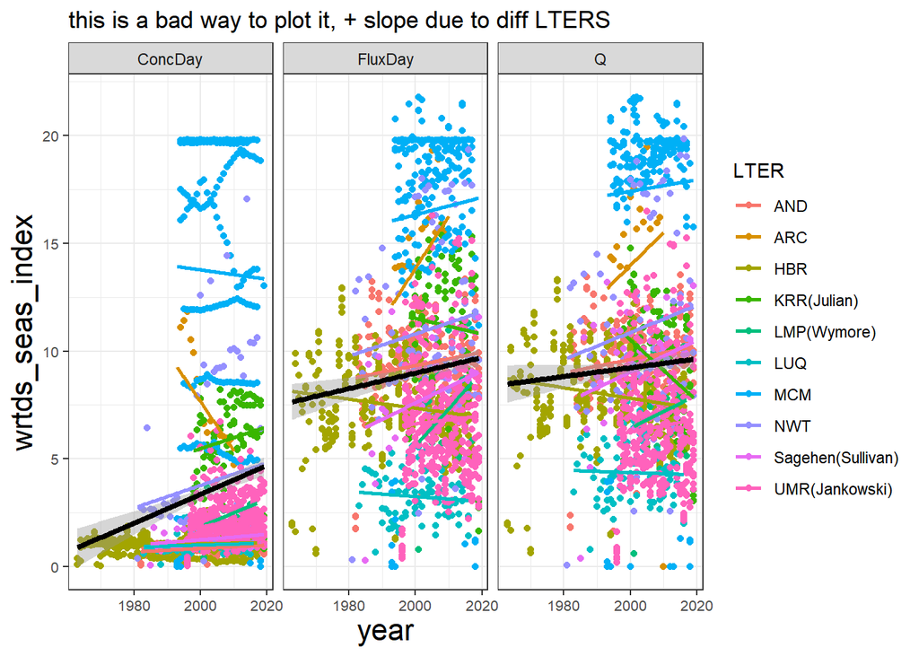

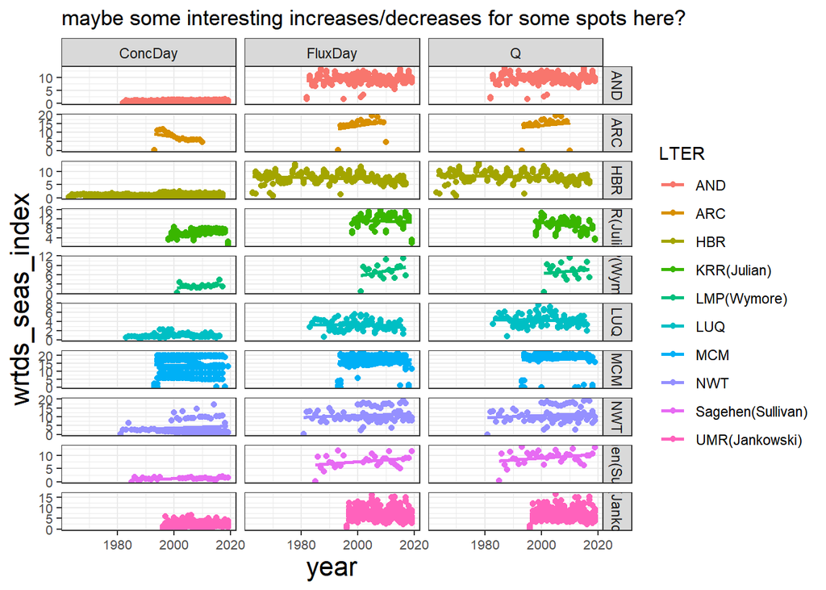

> and then calculating + plotting slopes of the seasonality index over time

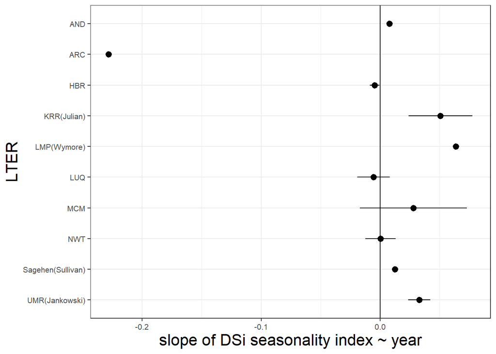

[figure not shown]

```
## # A tibble: 520 x 10
##    site  LTER  variable term  estimate std.error statistic p.value conf.low
##    <chr> <chr> <chr>    <chr>    <dbl>     <dbl>     <dbl>   <dbl>    <dbl>
##  1 Pris~ MCM   FNFlux   (Int~    -490.      288.     -1.70  0.105    -1094.
##  2 Pris~ MCM   FluxDay  (Int~    -489.      289.     -1.69  0.107    -1094.
##  3 Pris~ MCM   ConcDay  (Int~    -480.      296.     -1.62  0.122    -1101.
##  4 Pris~ MCM   FNConc   (Int~    -480.      296.     -1.62  0.122    -1101.
##  5 Imna~ ARC   FluxDay  (Int~    -470.      415.     -1.13  0.275    -1350.
##  6 LMP73 LMP(~ FluxDay  (Int~    -341.      238.     -1.43  0.173     -849.
##  7 Gree~ MCM   ConcDay  (Int~    -339.      150.     -2.26  0.0325    -648.
##  8 Gree~ MCM   FNConc   (Int~    -339.      150.     -2.26  0.0325    -647.
##  9 GSWS~ AND   FluxDay  (Int~    -311.      179.     -1.74  0.101     -690.
## 10 GSWS~ AND   Q        (Int~    -310.      180.     -1.72  0.105     -692.
## # ... with 510 more rows, and 1 more variable: conf.high <dbl>
```

```
##
## Random-Effects Model (k = 260; tau^2 estimator: REML)
##
##    logLik   deviance        AIC        BIC       AICc
##  217.9376  -435.8752  -431.8752  -424.7615  -431.8283
##
## tau^2 (estimated amount of total heterogeneity): 0 (SE = 0.0004)
## tau (square root of estimated tau^2 value):      0
## I^2 (total heterogeneity / total variability):   0.00%
## H^2 (total variability / sampling variability):  1.00
##
## Test for Heterogeneity:
## Q(df = 259) = 24.1155, p-val = 1.0000
##
## Model Results:
##
## estimate      se    zval    pval    ci.lb   ci.ub
##   0.0065  0.0063  1.0363  0.3001  -0.0058  0.0188
##
## ---
## Signif. codes:  0 '***' 0.001 '**' 0.01 '*' 0.05 '.' 0.1 ' ' 1
```

[figure not shown]

```
## # A tibble: 50 x 10
##    LTER  variable term  type  estimate std.error statistic p.value conf.low
##    <chr> <chr>    <chr> <chr>    <dbl>     <dbl>     <dbl>   <dbl>    <dbl>
##  1 AND   ConcDay  over~ summ~  0.00694    0.0196     0.354   0.723  -0.0314
##  2 AND   FluxDay  over~ summ~  0.0532     0.0723     0.736   0.462  -0.0885
##  3 AND   FNConc   over~ summ~  0.00599    0.0189     0.317   0.751  -0.0310
##  4 AND   FNFlux   over~ summ~  0.0303     0.0592     0.512   0.609  -0.0857
##  5 AND   Q        over~ summ~  0.0529     0.0728     0.727   0.467  -0.0898
##  6 ARC   ConcDay  over~ summ~ -0.228      0.349     -0.654   0.513  -0.913
##  7 ARC   FluxDay  over~ summ~  0.242      0.456      0.531   0.596  -0.651
##  8 ARC   FNConc   over~ summ~ -0.178      0.338     -0.525   0.599  -0.841
##  9 ARC   FNFlux   over~ summ~  0.139      0.396      0.350   0.726  -0.637
## 10 ARC   Q        over~ summ~  0.153      0.500      0.306   0.760  -0.828
## # ... with 40 more rows, and 1 more variable: conf.high <dbl>
```

```
## # A tibble: 50 x 4
## # Groups:   LTER [10]
##    LTER  variable num_obs mean_estimate
##    <chr> <chr>      <int>         <dbl>
##  1 AND   ConcDay        7       0.00792
##  2 AND   FluxDay        7       0.0707
##  3 AND   FNConc         7       0.00653
##  4 AND   FNFlux         7       0.0423
##  5 AND   Q              7       0.0711
##  6 ARC   ConcDay        1      -0.228
##  7 ARC   FluxDay        1       0.242
##  8 ARC   FNConc         1      -0.178
##  9 ARC   FNFlux         1       0.139
## 10 ARC   Q              1       0.153
## # ... with 40 more rows
```

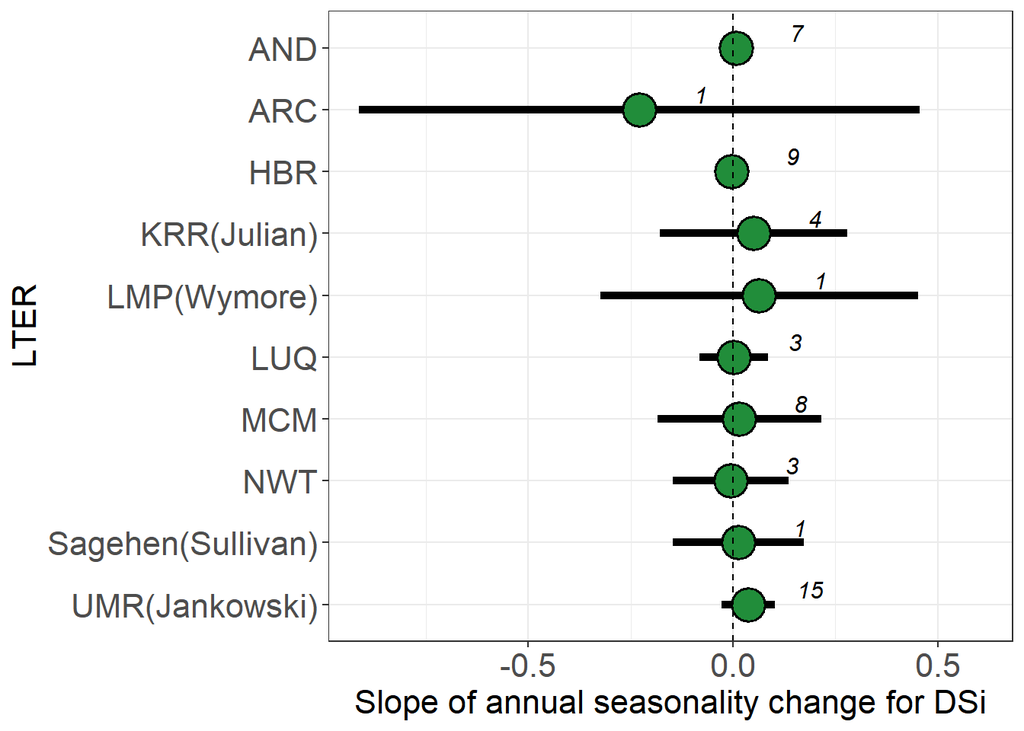

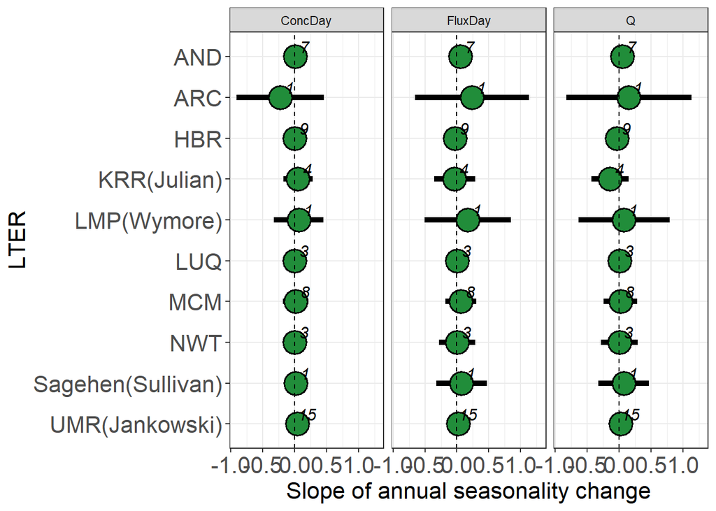

## 4.5 a super quick attempt at looking at how monthly averages have changed over time for each month and site, to get at whether certain months are increasing or decreasing

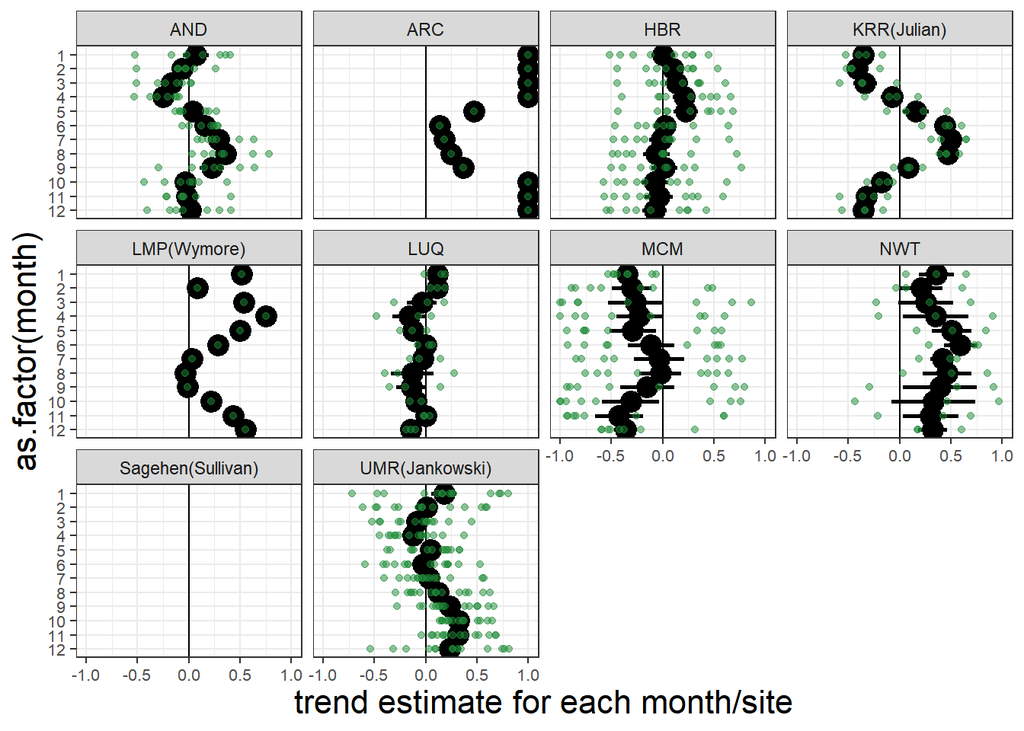

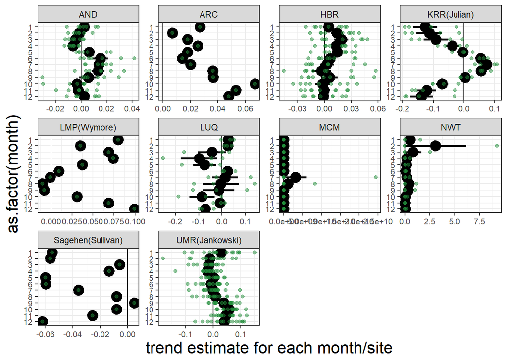